# Validating AI Breast-Cancer Risk Prediction in a Diverse Veteran Population

Two image-only AI models in ~69,000 women Veterans

Jessica Minnier

Knight Cancer Institute, OHSU, Portland, OR

Lina Gao

Knight Cancer Institute, OHSU, Portland, OR

Shauna Rakshe

Knight Cancer Institute, OHSU, Portland, OR

Shiuh-Wen Luoh

Knight Cancer Institute, OHSU & VA Portland Health Care System, Portland, OR

JSM 2026 · August 5, 2026

## Image-only AI: risk from a *normal* mammogram

- Estimates 5-year risk from a **negative** screening mammogram, using texture, asymmetry, and parenchymal pattern.
- Mirai (open source; the commercial Clairity Breast is the first FDA-authorized image-only 5-year risk tool)
- Has not been validated in **U.S. Veterans**, a population approximately one-third Black with military exposures absent from clinical models.

| Model class | Median AUC | Range |
| --- | --- | --- |
| Image-only AI | **0.72** | 0.62–0.90 |
| Clinical (Gail, Tyrer-Cuzick) | 0.61 | 0.54–0.69 |
| Image **+** clinical | **0.73** | 0.66–0.84 |

NCCN v1 (2026). Decision thresholds: **1.7%** 5-year (NCCN) · **3%** (USPSTF / ASCO).

We ask four questions: does it generalize, is it calibrated, is it clinically useful, and is it equitable?

## Scope

### Completed

- Discrimination, race x device
- Risk-quintile separation
- **Second model (AI-2) scored**
- Mirai vs. Tyrer-Cuzick
- Genetic benchmark (MVP)

### Proposed

- CIs, calibration
- Competing-risks absolute risk
- Decision curves
- Formal equity testing
- Mediation; AI + PRS + clinical

Work in progress. *Grant applications pending.*

## Cohort and pipeline

CDW:  
CPT-identified  
screening mammograms

VistA  
image pull

DICOM QC:  
device,  
4 views

ARCHES cloud:  
Mirai + AI-2  
scoring

Link outcomes,  
follow-up,  
race

| Cohort | Window | Size | Role |
| --- | --- | --- | --- |
| **Validation** | 2012–2015, 1st exam | **~69K** | All Mirai AUC + KM |
| Assembled | 2012–2019 | ~102K | 2,794 cancers; proposed |
| T-C comparison | 2023–2025, 4 sites | ~2,786 | Mirai vs. Tyrer-Cuzick |

## Validation cohort: 2012–2015, first exam

|  | Hologic | GE |
| --- | --- | --- |
| Mirai-scored | **46,998** | **21,566** |
| White or other / Black | 31,112 / 15,886 | 14,925 / 6,641 |
| Invasive cancers, 5 y / 10 y | 533 / 1,185 | 225 / 459 |
| Median follow-up | 11.28 y (IQR 10.0–12.6) | not computed |
| Median age | 53 y (IQR 46–59) | — |

**68,564 device-specific cohorts.**

Race is **CDW self-report**, not genetic ancestry; genome-informed ancestry exists only in the ~21% MVP-linked subset. Outcome: invasive cancer, ICD + treatment CPT, chart-validated. Diagnoses within 3 months excluded.

# Results

## Score distributions and threshold behavior

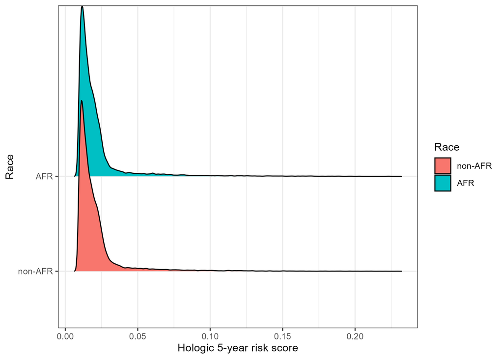

Hologic

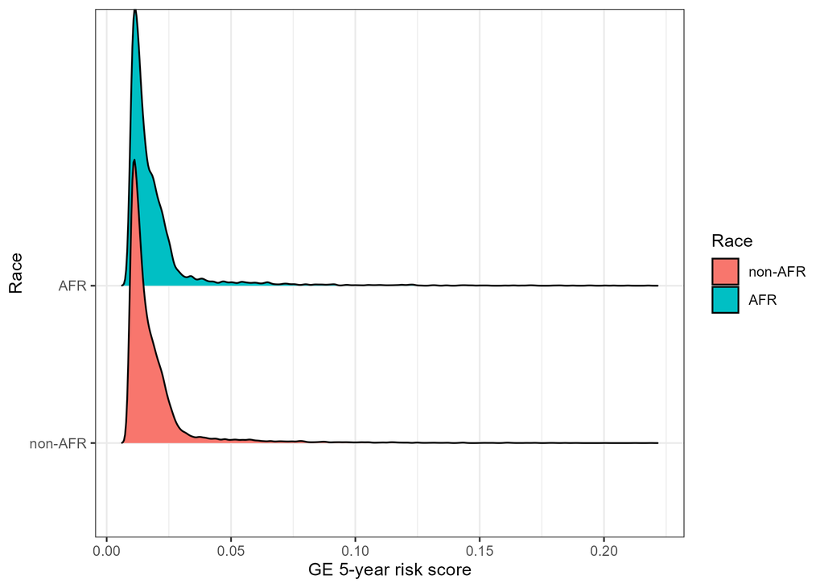

GE

- Median 5-year risk is **the same across race within a device**, but **differs between devices**.
- The NCCN **1.7%** threshold falls at the **40th–60th** percentile on Hologic and the **60th–80th** on GE.

Roughly half of Hologic-screened Veterans would be flagged, compared with a quarter of those screened on GE, despite equal AUCs.

Legends use analytic coding: **non-AFR = White or other, AFR = Black**.

## Discrimination: race x device

| Group | Device | 5-yr AUC | 10-yr AUC | N |
| --- | --- | --- | --- | --- |
| White or other | Hologic | 0.696 | 0.680 | 31,112 |
| Black | Hologic | 0.676 | 0.654 | 15,886 |
| White or other | GE | 0.697 | 0.686 | 14,925 |
| Black | GE | 0.676 | 0.661 | 6,641 |

- Discrimination is comparable across race and device, and somewhat below published registry validations (0.71–0.76).
- Censoring weights are marginal Kaplan-Meier rather than covariate-dependent.

## Breast-cancer-free survival by risk quintile

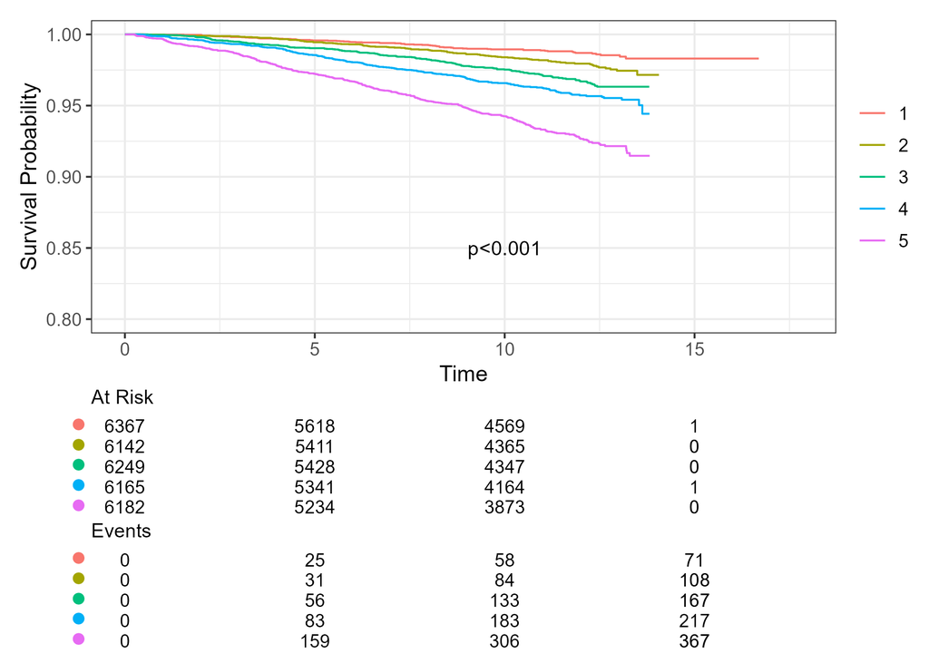

Hologic · White/other

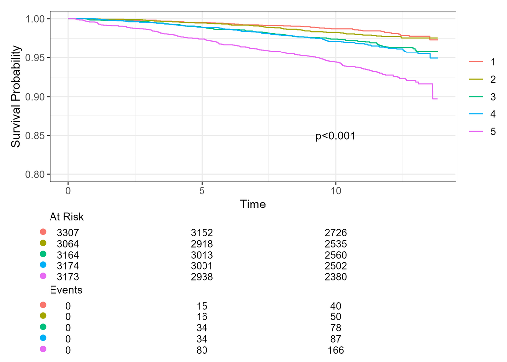

Hologic · Black

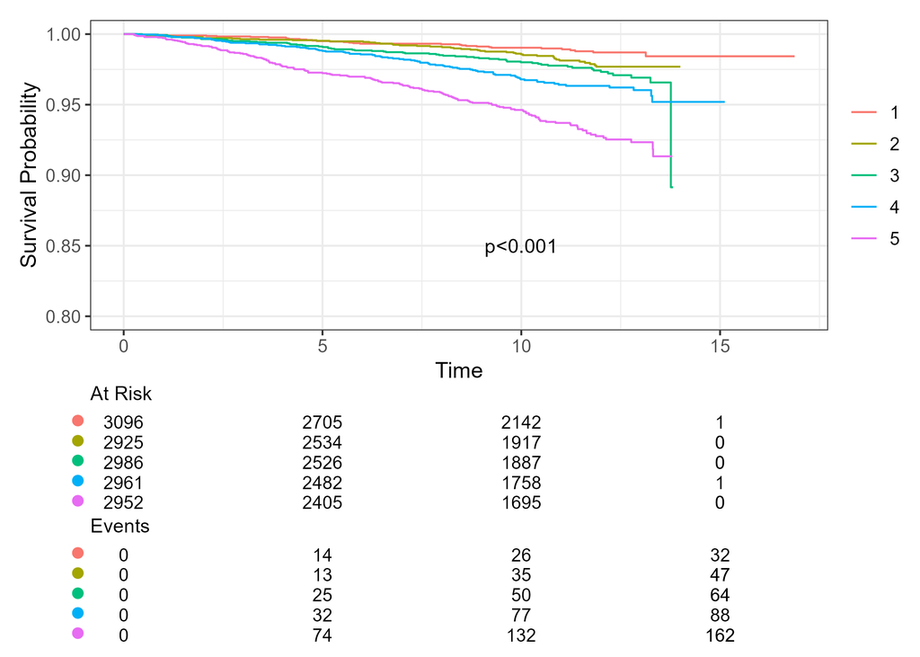

GE · White/other

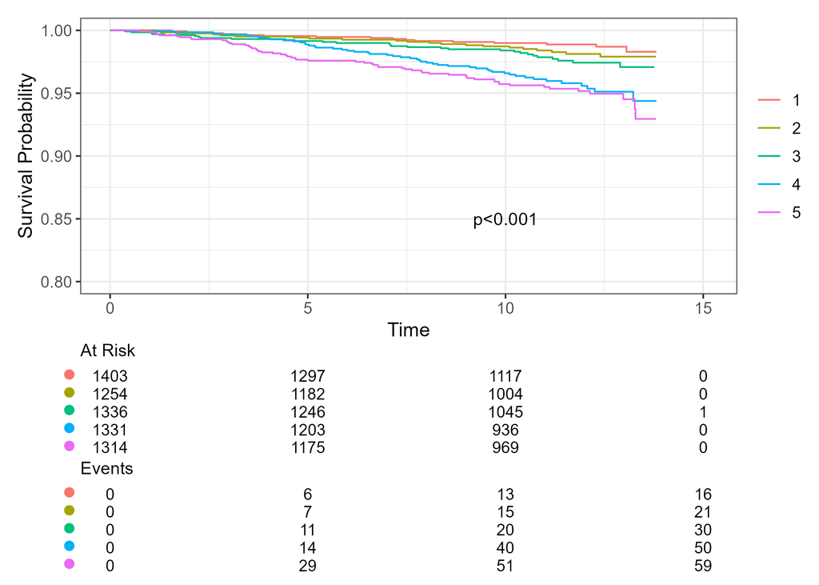

GE · Black

| Stratum | Q1 | Q5 | Q5 : Q1 |
| --- | --- | --- | --- |
| Hologic, White/other | 0.39% | 2.57% | **6.5x** |
| Hologic, Black | 0.45% | 2.52% | **5.6x** |
| GE, White/other | 0.45% | 2.51% | **5.5x** |
| GE, Black | 0.43% | 2.21% | **5.2x** |

The risk gradient is of similar magnitude in both race groups.

5-year naive cumulative incidence. Log-rank p < 0.001 in all four panels. Quintiles cut **within stratum** — panels not directly comparable.

## Two models, one cohort preliminary

| 5-year AUC | White or other | Black |
| --- | --- | --- |
| Mirai | 0.696 | 0.676 |
| **AI-2** | **0.671** | **0.696** |

## Agreement with the Tyrer-Cuzick model

|  | Mirai high | Mirai low |
| --- | --- | --- |
| **T-C high** | **19** | 123 |
| **T-C low** | 442 | 2,202 |

- Of the women Tyrer-Cuzick calls high risk, Mirai agrees on **13%**; of those Mirai calls high risk, Tyrer-Cuzick agrees on **4%**.
- kappa = -0.016 and -0.003, with both intervals covering zero: agreement is indistinguishable from chance.
- 1-year AUC was **0.84** for Mirai and **0.49** for Tyrer-Cuzick, based on **8 events**.

**Warning**

## Genetic benchmark (MVP)

| Model | White or other | Black |
| --- | --- | --- |
| BCRAT + PRS313 | 0.709 (0.685–0.733) | 0.654 (0.619–0.689) |
| PRS-AABCG | — | 0.563 (0.521–0.605) |
| PRS-AABCG + BCRAT | — | 0.641 (0.605–0.676) |

Genetic models show a comparable or larger performance gap, which motivates **combining imaging, genetic, and clinical signal** rather than selecting among them.

53.5K women, 818 incident cancers, median follow-up 5.7 y.

# From discrimination to a clinically useful tool

### the statistical agenda (proposed — grants pending)

## Competing risks

- With 10–12 years of follow-up in women aged 40–74, **death without breast cancer is not rare**.
- Our current analyses censor death, which is valid for **ranking** but not for a claim about **absolute risk**.
- Every decision threshold discussed here is an absolute-risk threshold.

**Plan:** cumulative incidence by **Aalen-Johansen**; **cause-specific Cox** as primary and **Fine-Gray** as secondary; **Gray's test** for descriptive strata only; the score kept **continuous** throughout; baseline hazards stratified by device and era.

`survival` · `cmprsk` · `timeROC` · `riskRegression` · `dcurves`

## Calibration and domain shift

- Discrimination seems to be preserved across device type but calibration is not; the score distributions shown earlier are an example.
- **O/E ratios**, **calibration slope and intercept**, and **ICI with E50/E90**, adapted to competing risks.
- Estimated within **race x device x era** strata.

**Recalibration:** split the 102K cohort by even and odd terminal MRN digit; apply logistic recalibration where miscalibration is approximately linear and **restricted cubic spline** recalibration where it is not; evaluate at the **1.7%** threshold.

We treat this as a **domain shift** problem across device (Hologic to GE) and era (FFDM to synthetic).

Calibration is assessed at 5 years only, since Mirai produces a 5-year risk and a 10-year assessment would require a prediction the model does not provide.

## Rarity, utility, equity

- At **1.1%** incidence, AUC can be misleading under class imbalance, so we add **AUPRC**, **IPA**, and the time-dependent **Brier score**.
- Clinical utility by **decision-curve net benefit**, with a **rule-out and rule-in threshold bracketing an equivocal zone** in place of a single optimal cut-point.
- Sensitivity, specificity, PPV, and NPV reported **by race and age**, since predictive values depend on prevalence.
- Equity assessed by a race x score interaction with Benjamini-Hochberg control, extended to **Hispanic and Asian** groups.

These strata are **self-reported race**, so any difference describes a population as recorded in the health system rather than a biological one.

All estimates and CIs by 10-fold CV with 1000 bootstrap resamples.

## Causal mediation with genetic instruments

**Does the AI score mediate the effect of known risk factors?** Establishing mediation would support the interpretability of the score.

- **Estimands:** natural direct and indirect effects, proportion mediated, and the controlled direct effect.
- **Estimator:** the regression-based approach of Valeri and VanderWeele (`CMAverse::cmest`), with a Cox outcome model including an exposure-mediator interaction and bootstrap intervals.
- **Identification:** the exposures are **genetically instrumented**, which addresses confounding of the exposure with both the outcome and the mediator.
- **Remaining assumption:** the instruments do not address confounding between mediator and outcome. This is untestable, so we assess its plausibility with **E-values**.
- **Collinearity:** breast density is itself a feature the model encodes, so we report the controlled direct effect alongside the natural effects.

Instruments: PRS-AAM, PRS-ANM, and polygenic scores for BMI and breast density. Simulation-based power: minimum detectable a-path of **0.03 SD** at 90%.

## Limitations

- Work in progress.
- Results to date address discrimination; death is censored rather than modeled as a competing event.
- Confidence intervals and calibration have not yet been computed.
- The Tyrer-Cuzick comparison, small cohort, limited follow-up.
- The AI-2 results are preliminary
- Strata are self-reported race rather than genetic ancestry.

## Conclusions

- Mirai discriminates comparably across race and device, with a **5–6.5-fold risk gradient between the top and bottom quintile** that is similar in Black women.
- A **second model reverses the direction of the race difference**, indicating that the difference is either not significant or clinically meaningful, or is specific to a model rather than to image-only AI.
- Image-based and clinical risk identify **largely non-overlapping** groups of women: 13% and 4% agreement.

Our contribution is the **evaluation framework**: calibration under domain shift, absolute risk under competing risks, net benefit, equity testing, and a mediation design that uses genetic instruments for identification.

## Acknowledgments & references

**Team:** S. Rakshe (analysis), L. Gao, J. Minnier (biostatistics), S-W. Luoh (clinical); Million Veteran Program; VA ARCHES; VA National Radiology Program.

1. Yala A, et al. Multi-institutional validation of a mammography-based risk model. *JCO* 2022.
2. Arasu VA, et al. Mammography AI vs a clinical risk model for 5-year risk. *Radiology* 2023.
3. Minnier J, et al. Polygenic breast-cancer risk in women Veterans (MVP). *JCO Precis Oncol* 2021.
4. Jia G, et al. GWAS of breast cancer in women of African ancestry. *Nat Genet* 2024.
5. Austin PC, Steyerberg EW. The Integrated Calibration Index. *Stat Med* 2019.
6. Valeri L, VanderWeele TJ. Mediation analysis with survival outcomes. *Psychol Methods* 2013.
7. Esserman LJ, et al. The WISDOM trial. *JAMA* 2026.

# Backup

## Backup · AI-2 risk-quintile survival

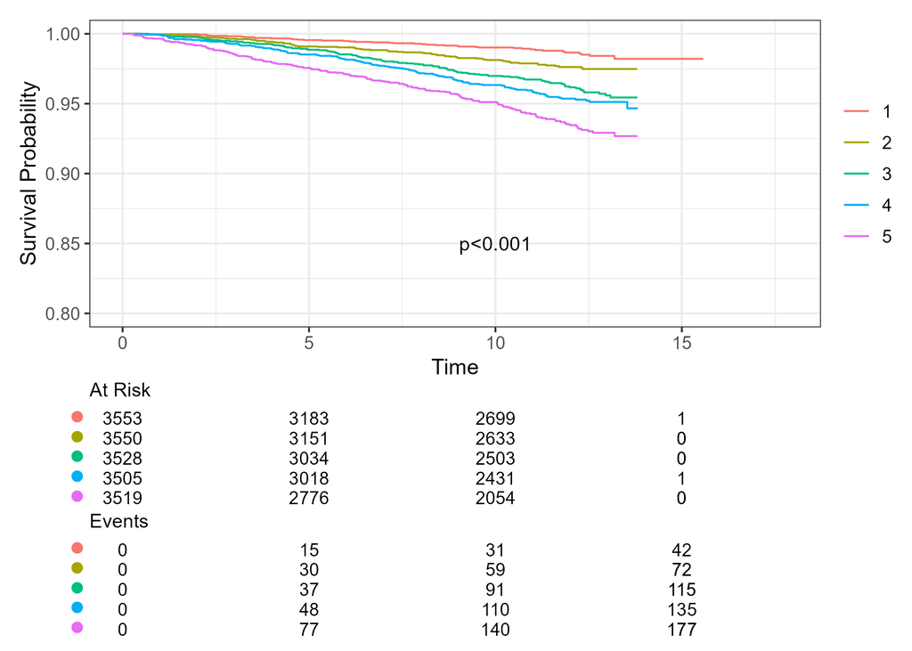

AI-2 · Hologic · White/other (N = 17,655)

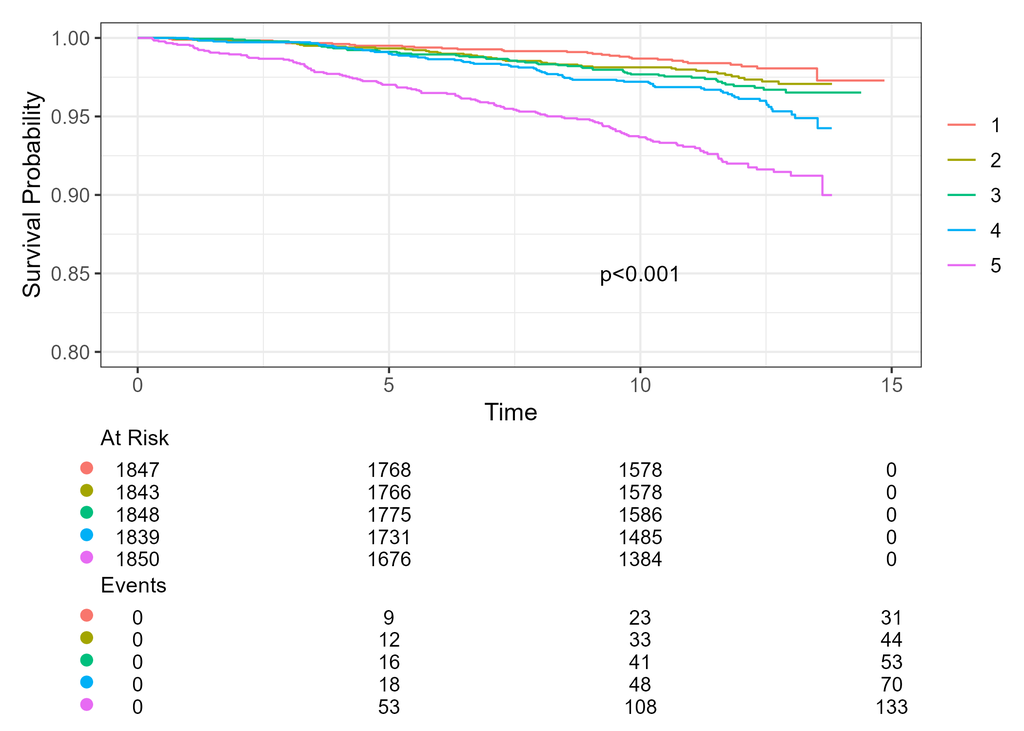

AI-2 · Hologic · Black (N = 9,227)

Log-rank p < 0.001 in both panels. The five-year risk ratio between the top and bottom quintile is 5.2 in White/other and 5.9 in Black women. In Black women, however, quintiles 1 through 4 are nearly flat (0.49% to 0.98%), and the separation comes almost entirely from the top quintile (2.86%).

## Backup · quintile event counts, Mirai

Cumulative invasive cancers (N at risk at t = 0):

| Quintile | Hologic White/other | Hologic Black | GE White/other | GE Black |
| --- | --- | --- | --- | --- |
| Q1 | 25 (6,367) | 15 (3,307) | 14 (3,096) | 6 (1,403) |
| Q2 | 31 (6,142) | 16 (3,064) | 13 (2,925) | 7 (1,254) |
| Q3 | 56 (6,249) | 34 (3,164) | 25 (2,986) | 11 (1,336) |
| Q4 | 83 (6,165) | 34 (3,174) | 32 (2,961) | 14 (1,331) |
| Q5 | 159 (6,182) | 80 (3,173) | 74 (2,952) | 29 (1,314) |
| **5-yr total** | **354** | **179** | **158** | **67** |
| **10-yr total** | 764 | 421 | 320 | 139 |

758 invasive cancers by 5 years across 68,564, a **1.1%** naive cumulative incidence.

## Backup · sensitivity to including DCIS

| Stratum | 5-yr excl. | 5-yr incl. | Diff | 10-yr excl. | 10-yr incl. | Diff |
| --- | --- | --- | --- | --- | --- | --- |
| Hologic, White/other | 0.696 | 0.694 | -0.002 | 0.680 | 0.681 | +0.001 |
| Hologic, Black | 0.676 | 0.668 | **-0.008** | 0.654 | 0.649 | -0.005 |
| GE, White/other | 0.697 | 0.690 | -0.007 | 0.686 | 0.681 | -0.005 |
| GE, Black | 0.676 | 0.674 | -0.002 | 0.661 | 0.670 | **+0.010** |

Including DCIS raises the GE-Black 10-year AUC by 0.010 and lowers the Hologic-Black 5-year AUC by 0.008. Because the effect is not uniform in direction, we retain invasive cancer as the primary outcome.

## Backup · AI-2 attrition and methods

| Step | N |
| --- | --- |
| Exams returned | 32,404 |
| After dropping failed predictions | 27,846 (**14.1% failure**) |
| First exam per patient, joined to cohort | 27,764 |
| Excluding cancer before / within 3 months of index | **26,882** |

- AI-2 returns a single 5-year risk estimate, with no density, detection, or multi-horizon output. Code for the GE and synthetic-2-D arms exists but has not been run.
- 53 women in the White/other stratum had exam dates after their last follow-up date; survival time was set to 0.
- Death dates are uncorrected, so death censors at last visit rather than at the date of death.
- Quintile cutpoints were computed within race stratum, as for Mirai.